# Capstone Project Coursera JHU Data Science

## Corpus of words - Removed profanity and not removed stopwords

```r
library(NLP);library(ngram);library(textclean);library(tm);library(data.table)
##getCorpus function cleans text data to output the clean corpus
##note: retained stopwords to improve the accuracy of models
options(mc.cores=1)#avoid hanging of Ngram tokenizer
getCorpus<- function(textdata){
    if (!require(tm)) {
        stop("Library tm is missing.")
    }
    if (!require(ngram)) {
        stop("Library ngram is missing.")
        }
    exp1 <- content_transformer(function(x,pattern) gsub(pattern,replacement =" ",x))
    exp2 <-content_transformer(function(x,pattern) gsub(pattern,replacement ="",x))
    corp<- VCorpus(VectorSource(textdata),list(readPlain,language="en"))
    corp<-tm_map(corp,content_transformer(tolower))
    corp <- tm_map(corp,exp1,"[[:alnum:]]+\\@[[:alpha:]]+\\.com")
    corp<- tm_map(corp,exp1,"[^a-z\\s]+")
    corp <- tm_map(corp,exp1,"\\(.*?\\)")
    corp<- tm_map(corp,removeWords,readRDS("profanityWords1.rds"))
    corp<-tm_map(corp,exp1,"[[:punct:]]+")
    corp<-tm_map(corp,exp2,"[\\']+")
    corp <- tm_map(corp,exp1,"(^[[:space:]]+|[[:space:]]+$)")
    corp<- tm_map(corp,exp1,"rt")
    corp<-tm_map(corp,stripWhitespace)
    corp<-tm_map(corp,removeNumbers)
    corp<-tm_map(corp,PlainTextDocument)
    return(corp)
}
## NOTE: As I already saved the files in the directory, not running the code as it takes about an hour. Hoewever, the code is included for the reference.
```

set.seed(16012020)

Training corpus

trainCorpus <- getCorpus(TrainData)

saveRDS(trainCorpus,“trainCorpus.rds”)

Development corpus

devCorpus <- getCorpus(DevData)

saveRDS(devCorpus,“devCorpus.rds”)

Test corpus

testCorpus <- getCorpus(TestData)

saveRDS(testCorpus,“testCorpus.rds”)

Save the files

save(TrainData,DevData,TestData, file=“textData.rda”)

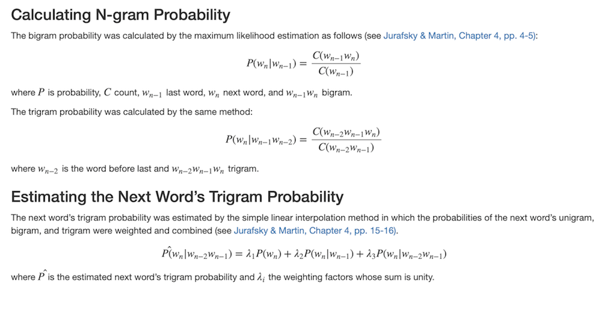

```r
library(knitr)
knitr::include_graphics(path="/Users/rizwanmohamed/Coursera/ngramfig.png")
```

## Get dataframes of ngrams, counts, probabilitites of the training, test and development data

```r
library(dplyr);library(tm);library(ngram);library(textclean);library(NLP)
##Set seed
set.seed(16012020)
##getNgrams function takes the corpus & n(= 1,2,3,4) as **INPUT** and returns the dataframe of Ngrams with col(ngrams, freq, prop) as **OUTPUT**.

getNgrams <- function(corpus, n=1) {
    if (!require(ngram)) {
        stop("Library ngram is missing.")
    }
    ## Convert corpus to a string
    str <-concatenate(as.character(unlist(corpus)))
    str<-replace_contraction(str)
    str <- stri_replace_all(str, replacement = "'", fixed = "’")
    str<- removeNumbers(str)
    str <- gsub("(^[[:space:]]+|[[:space:]]+$)", "", str)
    str<-str[!((str == "")|(str=="'"))]
    str<- removePunctuation(str,reserve_intra_word_dashes=TRUE)
    str<- gsub(" [b-hj-z] ", " ", str)
    str<- stripWhitespace(str)
    ngramDF <- ngram(str, n=n)
    return(get.phrasetable(ngramDF))
}
trainCorpus<- readRDS("trainCorpus.rds")
devCorpus<- readRDS("devCorpus.rds")
testCorpus<- readRDS("testCorpus.rds")
t1<-proc.time()
## Ngrams of training corpus: data frame of (ngrams, freq, prop)
train1grams <- getNgrams(trainCorpus,1)
head(train1grams,1)
```

```
## # A tibble: 1 x 3
##   ngrams   freq   prop
##   <chr>   <int>  <dbl>
## 1 "the " 503954 0.0511
```

```r
train2grams <- getNgrams(trainCorpus,2)
head(train2grams,1)
```

```
## # A tibble: 1 x 3
##   ngrams     freq    prop
##   <chr>     <int>   <dbl>
## 1 "in the " 44997 0.00457
```

```r
train3grams <- getNgrams(trainCorpus,3)
head(train3grams,1)
```

```
## # A tibble: 1 x 3
##   ngrams         freq     prop
##   <chr>         <int>    <dbl>
## 1 "one of the "  3909 0.000397
```

```r
save(train1grams,train2grams, train3grams,file="trainNGrams.rda")
## Ngrams of development corpus
dev1grams <- getNgrams(devCorpus,1)
dev2grams <- getNgrams(devCorpus,2)
dev3grams <- getNgrams(devCorpus,3)
save(dev1grams,dev2grams,dev3grams,file="devNGrams.rda")
## Ngrams of test corpus
test1grams <- getNgrams(testCorpus,1)
test2grams <- getNgrams(testCorpus,2)
test3grams <- getNgrams(testCorpus,3)
save(test1grams, test2grams, test3grams,file="testNGrams.rda")
## remove auxiliary data
save(train1grams,train2grams,train3grams,dev1grams,dev2grams,dev3grams,test1grams,test2grams,test3grams,file="Ngrams.rda")
t2<-proc.time()
print(t2-t1)
```

```
##    user  system elapsed
## 489.603   5.286 495.650
```

# Good Turing Method: Calculating the smoothed probabilites and counts of Ngrams

```r
## We'll use (1) Turing estimate = r(T), for small r and use (2) Linear Good-Turing estimate = r(LGT), for large r
## We'll switch to LGT when r(T) - r(LGT) > 1.65*sd, once switched to LGT, keep using LGT.
##
## simpleGT function takes **freqTable, a datatable of r (freq rate of Ngram)** and **Nr (freq of frequencies of Ngram)** as an INPUT to return the smoothed frequencies (rrstar) as OUTPUT.
## rrstar is a data table of r (freq) and rstar (freqGT) where freq = original frequencies and freqGT is frequencies of frequencies(Nr) smoothed by Good Turing method.
## The first row in the data table is the pair of freq=0 (frequency of unseen Ngrams) and freqGT at freq=0 (smoothed by the simple GT): (0,freqGT_at_0)

##**simpleGT function** to calculate smoothed probabilities and counts:
simpleGT <- function(freqTable) {
    ## nrz.est: Averaging transformation
    ## Replace nr by zr = nr/(0.5*(t - q))
    ## where q, r, t are successive indices of non-zero values
    nrz.est <- function(r, nr) {
        d <- c(1, diff(r))
        dr <- c(0.5 * (d[-1] + d[-length(d)]), d[length(d)])# sum(average of 1st& last element of d removed)+last element
        return(nr/dr)
    }
    ## rstest: Linear Good-Turing estimate for large r
    ## log(nr) = a + b * log(r)
    ## b = coef[2], intersect
    ## rstest r(star)est = r *(1 + 1/r)^(b + 1)
    ## b < -1, in gtfuncs.S by William A. Gale
    rstest <- function(r, coef) {
        return(r * (1 + 1/r)^(1 + coef[2]))
    }
    ## The following code comes from gtanal.S by William A. Gale
    ## Get the input xr and xnr
    xm <- freqTable
    xr <- xm[, 1]
    xnr <- xm[, 2]
    xN <- sum(xr * xnr)
    ## make averaging transform
    xnrz <- nrz.est(xr, xnr)
    ##(2) Linear Good-Turing estimate - took logs xr,xnr instead of xr and xnr
    xf <- lsfit(log(xr), log(xnrz))# least squares fit (y=a+bX)
    xcoef <- xf$coef
    xrst <- rstest(xr, xcoef)
    xrst_rel <- xrst/xr
    ##(1) Turing estimate
    xrtry <- xr == c(xr[-1]-1, 0)
    xrsta_rel <- rep(0, length(xr))
    xrsta_rel[xrtry] <- (xr[xrtry]+1) / xr[xrtry] * c(xnr[-1], 0)[xrtry] / xnr[xrtry]
    ## make switch from Turing to LGT estimates
    tursd <- rep(1, length(xr))
    for (i in 1:length(xr)) {
        tursd[i] <- (i+1) / xnr[i] * sqrt(xnr[i=1] * (1 + xnr[i+1] / xnr[i]))
    }
    xrstcmbrel <- rep(0, length(xr))
    useturing <- TRUE
    for (r in 1:length(xr)) {
        if (!useturing) {
            xrstcmbrel[r] <- xrst_rel[r]
        } else if (abs(xrst_rel - xrsta_rel)[r] * r / tursd[r] > 1.65) {
            xrstcmbrel[r] <- xrsta_rel[r]
        } else {
            useturing <- FALSE
            xrstcmbrel[r] <- xrst_rel[r]
        }
    }
    ## renormalize the probabilities for observed objects
    sumpraw <- sum(xrstcmbrel * xr * xnr / xN)
    xrstcmbrel <- xrstcmbrel * (1 - xnr[1]/xN) / sumpraw
    ## output matrix (0, r0est) + (xr, xnrstarnormalized)
    rrstar <- cbind(c(0, xr), c(xnr[1]/xN, xr*xrstcmbrel))
    ## output data table by pairs = (r = freq, rstar = freqGT)
    ## keyed (ordered) by freq
    rrstar <- data.table(rrstar)
    colnames(rrstar) <- c("freq", "freqGT")
    setkey(rrstar, freq)
    return(rrstar)
}
```

## Smoothing the Ngrams with Good-Turing algorithm to get the Ngrams dataframe with smoothed frequencies and prob at zero freq(Pzero).

```r
## INPUT = ngramDF**, is a Ngrams dataframe obtained from the getNgrams() & minimum frequency of Ngrams
## OUTPUT = list of a smoothed ngrams dataframe (ngramDT) & the probability of zero frequency (Pzero)
smoothedNgrams <- function(ngramDF, minFreq=2) {
    if (!require(stringr)) {
        stop("Library stringr is missing.")
    }
    ## Convert the data frame to datatable and rename columns
    colnames(ngramDF) <- c("ngram", "freq", "prob")
    ngramDT <- data.table(ngramDF)
    ## Remove ngrams with frequencies below the cutoff minFreq
    ngramDT <- ngramDT[freq >= minFreq]
    ## Get frequency (Nr) of frequency r,
    freqNf <- data.table(table(ngramDT[, "freq"]))
    colnames(freqNf) <- c("freq", "NFreq")
    freqNf <- sapply(freqNf, as.numeric)
    ## Get frequencies smoothed by Simple Good Turing method
    freqGT <- simpleGT(freqNf)
    ## Merge ngramDT with freqGT
    setkey(ngramDT,freq)
    ngramDT <- merge(ngramDT, freqGT)
    ## Calculate probability of zero frequency
    pZero <- freqGT[1, 2]/sum(c(1, freqNf[, "NFreq"]) * freqGT[, 2])
    ## Output = list of smoothed ngrams dataframe and probability of zero frequency
    ngramDT_Pzero <- list(ngramDT=ngramDT, pZero=pZero)
    return(ngramDT_Pzero)
}
```

# Functions to calculate the adjusted counts and probabilities of Ngrams

```r
##**Unigram**
## recal_1gram trims single words and calculates adjusted counts (frequencies) and probabilities: p(w1) = count(w1)/count(all w1)
## INPUT = ugramDT, a data table of smoothed unigrams, c(ngram, freq, prob, freqGT) from the list obtained from
## smoothedNgrams(),where freq = original freq, freqGT = freq smoothed by simple GT method.
## OUTPUT= ugramDT, a data table of (unigram, word1, freq, prob, freqGT, probGT),
## where probGT = probability calculated from freqGT
recal_1gram <- function(ugramDT) {
    if (!require(stringr)) {
        stop("Library stringr is missing.")
    }
    ## Trim trailing spaces
    ugramDT <-ugramDT$ngramDT
    ugramDT <-ugramDT[, word1 := str_trim(ngram)]
    setkey(ugramDT, word1)
    ## Reset unsmoothed frequencies and calculate words' probabilities
    ugramDT <- ugramDT[, freq := sum(freq), by=c("word1")]
    ugramTotalFreq <- sum(ugramDT$freq)
    ugramDT[, prob := freq/ugramTotalFreq]
    ## Reset smoothed frequencies and calculate words' probabilities
    ugramDT <- ugramDT[, freqGT := sum(freqGT), by=c("word1")]
    ugramTotalFreqGT <- sum(ugramDT$freqGT)
    ugramDT[, probGT := freqGT/ugramTotalFreqGT]
    ## Set key column
    setkey(ugramDT, word1)
    ## Reorder the columns in unigrams
    setcolorder(ugramDT, c("ngram", "word1","freq", "prob", "freqGT", "probGT"))
    return(ugramDT)
}
##**Bigrams**
## recal_2grams function splits the 2-grams of Bigram dataframe into two words, sets words not in the vocabulary to <UNK>,
## calculates adjusted counts (frequencies) and probabilities, $p(w2|w1) = count(w1,w2)/count(w1)$
## INPUT = bigramDt, a datatable of bigrams, c(ngram, freq, prob, freqGT) obtained from smoothedNgrams() & Vocab, a list of single words as vocabulary
## OUTPUT = bigramDt, a datatable with col(bigram, word1, word2, freq, prob, freqGT, probGT),
## where freq = original freq, freqGT = freq smoothed by simple GT method.
recal_2grams<- function(bigramDt, vocab) {
    if (!require(stringr)) {
        stop("Library stringr is missing.")
    }
    ## Split the bigram into words
    bigramSplits <- str_split(bigramDt$ngram, boundary("word"))
    bigramDt[, word1 := sapply(bigramSplits, function(x) x[1])]
    bigramDt[, word2 := sapply(bigramSplits, function(x) x[2])]
    ## Set words not in the vocabulary list to <UNK>
    bigramDt[!(word1 %in% vocab), word1 := "<UNK>"]
    bigramDt[!(word2 %in% vocab), word2 := "<UNK>"]
    ## Count instances of word1 word2 and word1 by freq (unsmoothed)
    bigramDt[, count_w1_w2 := sum(freq), by=c("word1", "word2")]
    bigramDt[, count_w1 := sum(freq), by=c("word1")]
    ## Calculate p(w2|w1) = count(w1,w2)/count(w1)
    bigramDt[, prob := count_w1_w2/count_w1]
    ## Count instances of word1 word2 and word1 by freqGT (smoothed)
    bigramDt[, count_w1_w2_GT := sum(freqGT), by=c("word1", "word2")]
    bigramDt[, count_w1_GT := sum(freqGT), by=c("word1")]
    ## Calculate p(w2|w1) = count(w1,w2)/count(w1) by freqGT
    bigramDt[, probGT := count_w1_w2_GT/count_w1_GT]
    ## Remove temporary columns
    bigramDt[, c("count_w1_w2", "count_w1", "count_w1_w2_GT", "count_w1_GT") := NULL]
    ## Set key columns
    setkey(bigramDt, word1, word2)
    ## Reorder the columns in bigrams
    setcolorder(bigramDt, c("ngram", "word1", "word2","freq", "prob", "freqGT", "probGT"))
    return(bigramDt)
}
##**Trigrams**
## recal_3grams function:
## splits the 3-grams into three words (w1,w2,w3), sets words not in the vocabulary to <UNK>, recalculates frequencies and probability:
## p(w3|w1w2) = count(w1,w2,w3)/count(w1,w2)
## INPUT = trigramDt, a datatable of triigrams, c(ngram, freq, prob, freqGT) obtained from smoothedNgrams() & Vocab, a list of single words as vocabulary
## OUTPUT = trigramDt, a datatable with col(trigrams,word1,word2,word3,freq, prob, freqGT, probGT),where freq = original freq, freqGT = freq smoothed by simple GT method.
recal_3grams <- function(trigramDt, vocab) {
    if (!require(stringr)) {
        stop("Library stringr is missing.")
    }
    ## Split the bigram into words
    trigramSplits <- str_split(trigramDt$ngram, boundary("word"))
    trigramDt[, word1 := sapply(trigramSplits, function(m) m[1])]
    trigramDt[, word2 := sapply(trigramSplits, function(m) m[2])]
    trigramDt[, word3 := sapply(trigramSplits, function(m) m[3])]
    ## Set words not in the vocabulary list to <UNK>
    trigramDt[!(word1 %in% vocab), word1 := "<UNK>"]
    trigramDt[!(word2 %in% vocab), word2 := "<UNK>"]
    trigramDt[!(word3 %in% vocab), word3 := "<UNK>"]
    ## Count instances of word1 word2 word3 and word1 word2 by freq (unsmoothed)
    trigramDt[, count_w1_w2_w3 := sum(freq), by=c("word1", "word2", "word3")]
    trigramDt[, count_w1_w2 := sum(freq), by=c("word1", "word2")]
    ## Calculate p(w3|w1w2) = count(w1,w2,w3)/count(w1,w2)
    trigramDt[, prob := count_w1_w2_w3/count_w1_w2]
    ## Count instances of word1 word2 word3 and word1 word2 by freqGT (smoothed)
    trigramDt[, count_w1_w2_w3_GT := sum(freqGT), by=c("word1", "word2", "word3")]
    trigramDt[, count_w1_w2_GT := sum(freqGT), by=c("word1", "word2")]
    ## Calculate p(w3|w1w2) = count(w1,w2,w3)/count(w1,w2) by freqGT
    trigramDt[, probGT := count_w1_w2_w3_GT/count_w1_w2_GT]
    ## Remove temporary columns
    trigramDt[, c("count_w1_w2_w3", "count_w1_w2","count_w1_w2_w3_GT", "count_w1_w2_GT") := NULL]
    setkey(trigramDt, word1, word2, word3)
    ## Reorder the columns in trigrams
    setcolorder(trigramDt, c("ngram", "word1", "word2", "word3", "freq", "prob", "freqGT", "probGT"))
    return(trigramDt)
}
```

# Final Unigrams, Bigrams and Trigrams with adjusted counts and probabilities after smoothing

```r
#  Unigrams function converts a 1-gram dataframe into a data table, removes words with frequencies less than the minFreq,
## smoothes the frequencies by the Simple Good-Turing method,and recalculates frequencies and probabilities.
## INPUTS = ugramDF, a 1-gram dataframe obtained from the getNgrams() & a minimum frequency
## OUTPUT = ugramDT_Pzero, a data table of 1-grams, with cols(ngram, word1, freq, prob, freqGT, probGT) &
## pZero, smoothed frequency of an unobserved unigram.
Unigrams<- function(ugramDF, minFreq) {
    ugramDT_Pzero <- smoothedNgrams(ugramDF, minFreq)
    ugramDT_Pzero$ngramDT<- recal_1gram(ugramDT_Pzero)
    return(ugramDT_Pzero)
}
##
#  Bigrams function converts a 2-gramS dataframe into a datatable, removes words with frequencies less than the minFreq,
## smoothes the frequencies by the Simple Good-Turing method,and recalculates frequencies and probabilities.
## INPUT = bigramDF, a 2-gram dataframe obtained from the getNgrams() & a minimum frequency
## OUTPUT = ugramDT_Pzero, a datatable of 2-grams with cols(ngram, word1,word2,freq, prob, freqGT, probGT) &
## pZero, smoothed frequency of an unobserved bigrams.
Bigrams<- function(bigramDF, minFreq,vocab) {
    BigramDT_Pzero <- smoothedNgrams(bigramDF, minFreq)
    BigramDT_Pzero$ngramDT<- recal_2grams(BigramDT_Pzero$ngramDT,vocab)
    return(BigramDT_Pzero)
}
##
#  Trigrams function converts a 3-gramS dataframe into a datatable, removes words with frequencies less than the minFreq,
## smoothes the frequencies by the Simple Good-Turing method,and recalculates frequencies and probabilities.
## INPUT = trigramDF, a 3-gram dataframe obtained from the getNgrams() & a minimum frequency
## OUTPUT = trigramDT_Pzero, a datatable of 3-grams with cols(ngram,word1,word2,word3,freq, prob, freqGT, probGT) &
## pZero, smoothed frequency of an unobserved trigrams.
Trigrams<- function(trigramDF, minFreq,vocab) {
    TrigramDT_Pzero <- smoothedNgrams(trigramDF, minFreq)
    TrigramDT_Pzero$ngramDT<- recal_3grams(TrigramDT_Pzero$ngramDT,vocab)
    return(TrigramDT_Pzero)
}
```

## Extracting all possible last words given a word or first two words of ngram

```r
#**bigram_lastWords:**
## extracts all the bigrams containing the input first word (newWord1) along with the frequecies and probabilities
## INPUT = bgramDt, a datatable of recalculted bigrams obtained from Bigrams() &
## newWord1: the first word of bigram
## OUTPUT = bNextWords, a datatable of all bigrams containing the newWord1 along with the frequecies and probabilities.
bigram_lastWords <- function(bigramDt, newWord1) {
    bNextWords <- subset(bigramDt, word1==newWord1)
    bNextWords <- bNextWords[word2 != "<UNK>", ]
    return(bNextWords)
}
##
#**2.trigram_lastWords:**
## extracts all the trigrams containing the input first two words (newWord1,newWord2) along with the frequecies and probabilities
## INPUT = trigramDt, a datatable of recalculted trigrams obtained from Trigrams(),
## newWord1: the first word of trigram &
## newWord2: the second word of trigram
## OUTPUT = tNextWords, a datatable of all trigrams containing the newWord1 along with the frequecies and probabilities.
trigram_lastWords <- function(trigramDt, newWord1, newWord2) {
    tNextWords <- subset(trigramDt, word1==newWord1 & word2==newWord2)
    tNextWords <- tNextWords[word3 != "<UNK>", ]
    return(tNextWords)
}
```

## Examine the next word functions

```r
set.seed(16012020)
###example.1
library(stringr)
load("trainNGrams.rda")
## set vocabulary (with minimum frrequency =9):
unigramPzero_freq9<- Unigrams(train1grams,minFreq = 9)
vocab_freq9 <- unigramPzero_freq9$ngramDT$word1 #list of single words
##vocab size: r`length(vocab_freq9)`

bigramDt_train <- Bigrams(train2grams,minFreq = 2,vocab = vocab_freq9)
nextWord_how<-bigram_lastWords(bigramDt_train$ngramDT,"how")
head(nextWord_how)
```

```
## # A tibble: 6 x 7
##   ngram         word1 word2   freq    prob freqGT  probGT
##   <chr>         <chr> <chr>  <int>   <dbl>  <dbl>   <dbl>
## 1 "how about "  how   about    532 0.0356   535.  0.0357
## 2 "how am "     how   am       286 0.0191   287.  0.0192
## 3 "how anyone " how   anyone    75 0.00502   74.5 0.00497
## 4 "how are "    how   are      267 0.0179   268.  0.0179
## 5 "how best "   how   best     226 0.0151   227.  0.0151
## 6 "how big "    how   big      175 0.0117   175.  0.0117
```

```r
trigramDt_train <- Trigrams(train3grams,minFreq = 2,vocab = vocab_freq9)
nextWord_how_are<-trigram_lastWords(trigramDt_train$ngramDT,"how","are")
nextWord_how_are
```

```
## # A tibble: 2 x 8
##   ngram          word1 word2 word3  freq    prob  freqGT  probGT
##   <chr>          <chr> <chr> <chr> <int>   <dbl>   <dbl>   <dbl>
## 1 "how are we "  how   are   we        2 0.00749   0.861 0.00321
## 2 "how are you " how   are   you     265 0.993   268.    0.997
```

**Prediction model based on katz-backoff linear interpolation method**with Good-Turing smoothing algorithm**

```r
options(mc.cores=1)
#  bigram.func:
## This model predicts the last words(next word given first word) of a bigram. If not found, reports the most frequent unigram.
## INPUTS:
## lastWord = the first word of a bigram
## ugramPzero = datatable of unigrams and zero frequency
## bgramPzero = datatable of bigrams and zero frequency
## tgramPzero = datatable of trigrams and zero frequency
## coef = coefficients of the linear model of uni-, bi-, and tri-grams calculated using simplex method on the development ngrams
##
## OUTPUT = prediction, a datatable of bigrams with the known first word and cols(ngram, word1, word2, freq, prob, freqGT, probGT,
## ungram, ufreq, uprob, ufreqGT, uprobGT, tprobGT, predictProb)
##
## Predicted Word Probability(predictProb) = coef[1]*uprobGT + coef[2]*probGT + coef[3]*tprobGT
bigram.func <- function(lastWord, coef, ugramPzero, bgramPzero, tgramPzero) {
    if (!require(data.table)) {
        stop("Library data.table is missing.")
    }
    newWord1 <- lastWord
    if ("<UNK>" %in% newWord1) return(data.table())
    ## Get bigrams
    bNextWords <- bigram_lastWords(bgramPzero$ngramDT, newWord1)
    if (dim(bNextWords)[1] > 0) {
        ## Get probabilities of unigrams = nextWord
        setkey(bNextWords, word2)
        setkey(ugramPzero$ngramDT, word1)
        bNextWords <- bNextWords[ugramPzero$ngramDT, nomatch=0L]
        names(bNextWords) <- gsub("i.", "u", names(bNextWords))
        ## Add probability of trigram at zero frequency
        bNextWords[, tprobGT := tgramPzero$pZero]
        ## Calculate trigram probabilities
        bNextWords[, predictProb := coef[1]*uprobGT + coef[2]*probGT + coef[3]*tprobGT]
        ## Sort predicted probabilities in decreasing order
        setorder(bNextWords, -predictProb)
        prediction <- bNextWords
    }
    else {
        ## Get the most frequent word if trigrams and bigrams not found
        uNextWords <- ugramPzero$ngramDT[order(-probGT)][1]
        ## Add probabilities of bigrams and trigrams at zero frequency
        uNextWords[, bprobGT := bgramPzero$pZero]
        uNextWords[, tprobGT := tgramPzero$pZero]
        ## Calculate trigram probabilities
        uNextWords[, predictProb := coef[1]*probGT + coef[2]*bprobGT + coef[3]*tprobGT]
        prediction <- uNextWords
    }
    return(prediction)
}
#
#**predict.func:**
## This trigram predictiion model predicts the last words(third word given first two words) of a trigram. If not found, reports the most frequent bigrams of the second word.
## If not found, reports the most frequent unigrams
## INPUTS:
## lastWords = list of the first two words of a trigram = c(newWord1, newWord2)
## ugramPzero = datatable of unigrams and zero frequency
## bgramPzero = datatable of bigrams and zero frequency
## tgramPzero = datatable of trigrams and zero frequency
## coef = coefficients of the linear model of uni-, bi-, and tri-grams calculated using simplex method on the development ngrams
##
## OUTPUT = prediction, data table of trigrams with the known first word, cols(ngram, word1, word2, word3, freq, prob, freqGT, probGT, bngram, bfreq, bprob,
## bfreqGT, bprobGT, ungram, ufreq, uprob, ufreqGT, uprobGT, predictProb)
## nKeep = number of rows to keep for prediction
## Predicted Word Probability, predictProb = coef[1]*uprobGT + coef[2]*bprobGT + coef[3]*tprobGT
##
predict.func <- function(lastWords, coef, ugramPzero, bgramPzero, tgramPzero,nKeep) {
    if (!require(data.table)) {
        stop("Library data.table is missing.")
    }
    newWord1 = lastWords[[1]]
    newWord2 = lastWords[[2]]
    if ("<UNK>" %in% newWord2) return(data.table())
    ## Get trigrams of two new words
    tNextWords <- trigram_lastWords(tgramPzero$ngramDT, newWord1, newWord2)
    if (nrow(tNextWords) > 0) {
        ## Get probabilities of bigrams = newWord2 nextWord
        setkey(tNextWords, word2, word3)
        setkey(bgramPzero$ngramDT, word1, word2)
        tNextWords <- tNextWords[bgramPzero$ngramDT, nomatch=0L]
        names(tNextWords) <- gsub("i.", "b", names(tNextWords))
        ## Get probabilities of unigrams = nextWord
        setkey(tNextWords, word3)
        setkey(ugramPzero$ngramDT, word1)
        tNextWords <- tNextWords[ugramPzero$ngramDT, nomatch=0L]
        names(tNextWords) <- gsub("i.", "u", names(tNextWords))
        ## Calculate trigram probabilities as the sum of three weighted
        ## probabilities: unigram, bigram, and trigram.
        ## The Jelinek & Mercer method
        ## see https://english.boisestate.edu/johnfry/files/2013/04/bigram-2x2.pdf
        ## p'(wi|w_i-2, w_i-1) = c1*p(wi) + c2*p(wi|w_i-1) + c3*p(wi|w_i_2,w_i-1)
        ##
        ## Suggeted coef=c(0.1, 0.3, 0.6)
        tNextWords[, predictProb := coef[1]*uprobGT + coef[2]*bprobGT + coef[3]*probGT]
        ## Sort predicted probabilities in decreasing order
        setorder(tNextWords, -predictProb)
        prediction <- tNextWords
    } else
        {
        ## Get bigrams if trigrams not found
        prediction <- bigram.func(newWord2, coef, ugramPzero, bgramPzero, tgramPzero)
    }
    if (nrow(prediction) > nKeep) {
        prediction<- prediction[1:nKeep, ]# first ten matches
    }
    return(prediction)
}
## trigramProb: gets the probability of a trigram in the prediction datatable
## INPUTS:
## triWords = list of three words in the trigram
## prediction = data table of prediction from the first two words
## triPzero = smoothed frequency of an unobserved trigram
## triProb = probability of the trigram if found, or triPzero
##
trigramProb <- function(triWords, prediction, triPzero) {
    cnames <- colnames(prediction)
    checkWords <- c("word1", "word2", "word3")
    if (sum(checkWords %in% cnames) == 3) {
        prediction <- prediction[word1 == triWords[[1]] & word2 == triWords[[2]] & word3 == triWords[[3]]]
        triProb <- ifelse(dim(prediction)[1] > 0, prediction[1, "predictProb"], triPzero)
    }
    else {
        triProb <- triPzero
    }
    return(triProb)
}
```

**PredictNextWord function takes text/phrase(string) as an input (text variable) to predict the next word**

```r
library(textclean)
## predict_Nxtword: get the next words for the input string from Model
## Required libraries: tm, data.table, stringr
## Required functions: preprocessData, readTextFile
## input: the string
## nextWords: output, up to three words predicted
predict_Nxtword <- function(input) {
    simpleCorp<- function(x){
    corp<- SimpleCorpus(VectorSource(x))
    corp<-tolower(corp)
    Str<- unlist(corp)[[1]]
    return(Str)
    }
    ## Check for an empty string
    if (input== "") {
        return("<UNK>")
    }
    ## Clean text string
    Str<-simpleCorp(input)
    ## Convert corpus to a string
    Str <-concatenate(as.character(unlist(Str)))
    if (Str == " ") {
        return("<UNK>")
    }
    Str<-removeNumbers(Str)
    ## Split the clean string into words
    inputWords <- str_split(Str, boundary("word"))[[1]]
    if (length(inputWords) > 1) {
        testWords <- tail(inputWords, 2)
    } else if (length(inputWords) > 0) {
        testWords <- c("<UNK>", tail(inputWords, 1))
    } else {
        return("<UNK>")
    }
    coef<-c(0.1,0.3,0.6)# from simplex method
    predictions <- predict.func(testWords,coef,ugramPzero,bgramPzero,tgramPzero,3)
    cnames <- colnames(predictions)
    if ("word3" %in% cnames) {
        nextWords <- predictions$word3
    } else if ("word2" %in% cnames) {
        nextWords <- predictions$word2
    } else {
        nextWords <- predictions$word1
    }
    return(nextWords)
}
```

**Explore the model with example variables**

```r
set.seed(16012020)
###example.2
coef1 <-c(0.1,0.3,0.6)
ugramPzero.f9 <-Unigrams(train1grams,minFreq = 9)
vocab_f9 <- ugramPzero.f9$ngramDT$word1
bgramPzero.f92 <-Bigrams(train2grams,minFreq = 2,vocab_f9)
tgramPzero.f922<- Trigrams(train3grams,minFreq = 2,vocab_f9)
pred1 <-bigram.func(lastWord ="how",coef = coef1,ugramPzero.f9, bgramPzero.f92, tgramPzero.f922)
head(pred1,5)
```

```
## # A tibble: 5 x 14
##   ngram word1 word2  freq   prob freqGT probGT ungram  ufreq   uprob ufreqGT
##   <chr> <chr> <chr> <int>  <dbl>  <dbl>  <dbl> <chr>   <int>   <dbl>   <dbl>
## 1 "how… how   you    1527 0.102   1537. 0.103  "you "  84755 8.61e-3  84816.
## 2 "how… how   the     712 0.0477   716. 0.0478 "the " 503954 5.12e-2 504317.
## 3 "how… how   much    902 0.0604   908. 0.0606 "much…   8171 8.30e-4   8176.
## 4 "how… how   it      661 0.0442   665. 0.0444 "it "   93791 9.52e-3  93858.
## 5 "how… how   i       603 0.0404   606. 0.0405 "i "   186332 1.89e-2 186466.
## # … with 3 more variables: uprobGT <dbl>, tprobGT <dbl>, predictProb <dbl>
```

```r
##
pred2 <-predict.func(c("how","are"),coef =coef1,ugramPzero.f9,bgramPzero.f92,tgramPzero.f922,nKeep = 5)
head(pred2)
```

```
## # A tibble: 2 x 19
##   ngram word1 word2 word3  freq    prob  freqGT  probGT bngram bfreq   bprob
##   <chr> <chr> <chr> <chr> <int>   <dbl>   <dbl>   <dbl> <chr>  <int>   <dbl>
## 1 "how… how   are   you     265 0.993   268.    0.997   "are …  1189 0.0227
## 2 "how… how   are   we        2 0.00749   0.861 0.00321 "are …   116 0.00222
## # … with 8 more variables: bfreqGT <dbl>, bprobGT <dbl>, ungram <chr>,
## #   ufreq <int>, uprob <dbl>, ufreqGT <dbl>, uprobGT <dbl>, predictProb <dbl>
```